# Political Contribution in Profitable Business

# 營利事業政治捐獻分析

```
## ─ Attaching packages ───────────────────────────────── tidyverse 1.2.1 ─
```

```
## ─ Conflicts ────────────────────────────────── tidyverse_conflicts() ─
```

```r
per16 <- read.csv("political_contribution/2016/A05_basic_all.csv", header = TRUE, sep = ",")
don16 <- read.csv("political_contribution/2016/A02_company_all_public.csv", header = TRUE, sep = ",")

per12 <- read.csv("political_contribution/2012/A15_basicall_8.csv", header = TRUE, sep = ",")
don12 <- read.csv("political_contribution/2012/political_donation_8_od.csv", header = TRUE, sep = ",")

per08 <- read.csv("political_contribution/2008/A16_basicall_7.csv", header = TRUE, sep = ",")
don08 <- read.csv("political_contribution/2008/political_donation_7_od.csv", header = TRUE, sep = ",")
```

### 資料前處理

```r
don08 <- select(don08, - 填答數 , - 其他)
don12 <- select(don12, - 收支科目, - 填答數 , - 其他)
don16 <- select(don16, - 推薦政黨, - 當選註記, - 序號, - 收支科目, - 支出金額, - 金錢類, - P)
colnames(don16)[1] <- "姓名"
colnames(don08)[4] <- "統一編號"
colnames(don12)[5] <- "統一編號"
don12$統一編號 <- as.character(don12$統一編號)
don16$統一編號 <- as.character(don16$統一編號)
don08$屆數 <- as.character(don08$屆數)
don12$屆數 <- as.character(don12$屆數)
don16 <- cbind(don16, 屆數 = "9")
donall <- bind_rows(bind_rows(don08, don12), don16)

per08 <- cbind(per08, 屆數 = "7")
per12 <- cbind(per12, 屆數 = "8")
per16 <- cbind(per16, 屆數 = "9")
per16 <- per16[,c(-3, -9, -12, -15, -17, -19, -21, -23, -25, -26, -27)]
per16[,11] <- as.integer(gsub("," ,"", per16[,11]))
per16[,12] <- as.integer(gsub("," ,"", per16[,12]))
per16[,13] <- as.integer(gsub("," ,"", per16[,13]))
per16[,14] <- as.integer(gsub("," ,"", per16[,14]))
per16[,15] <- as.integer(gsub("," ,"", per16[,15]))
per16[,16] <- as.integer(gsub("," ,"", per16[,16]))
perall <- bind_rows(bind_rows(per08, per12), per16)
```

## 三屆以來登記在案的政治獻金流量變化

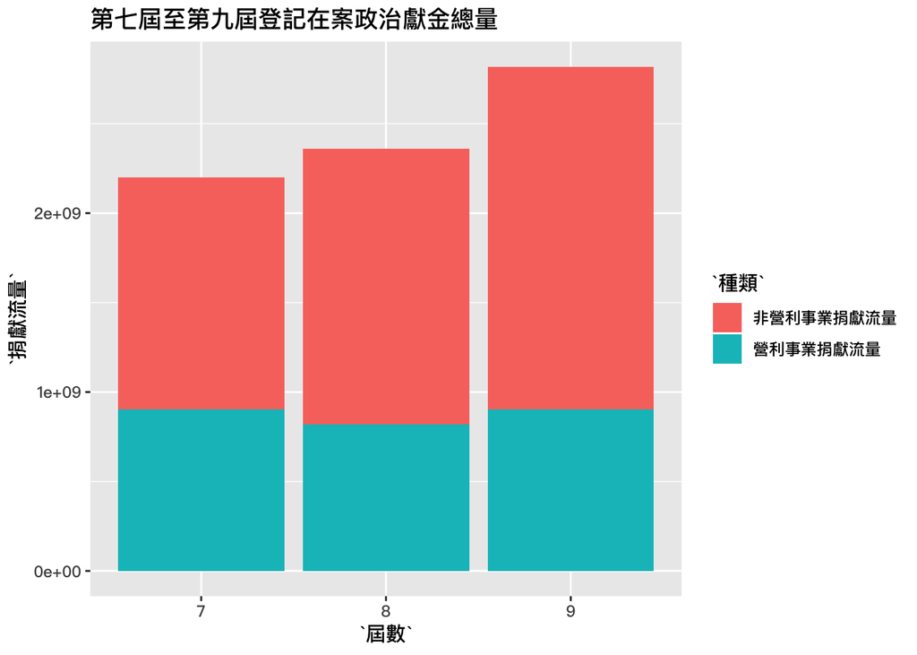

```r
perall %>%
  select(屆數, 總收入, 營利事業捐贈收入) %>%
  mutate(非營利事業捐贈收入 = 總收入 - 營利事業捐贈收入) %>%
  group_by(屆數) %>%
  summarise(營利事業捐獻流量 = sum(營利事業捐贈收入), 非營利事業捐獻流量 = sum(非營利事業捐贈收入)) %>%
  gather(種類, 捐獻流量, 營利事業捐獻流量, 非營利事業捐獻流量) %>%
  ggplot(aes(x = 屆數, y = 捐獻流量, fill = 種類)) +
  geom_bar(stat = "identity") +
  ggtitle("第七屆至第九屆登記在案政治獻金總量") +
  theme(text = element_text(family = "PingFangTC-Medium"))
```

## 三屆以來參與捐蹭營利事業的總數變化

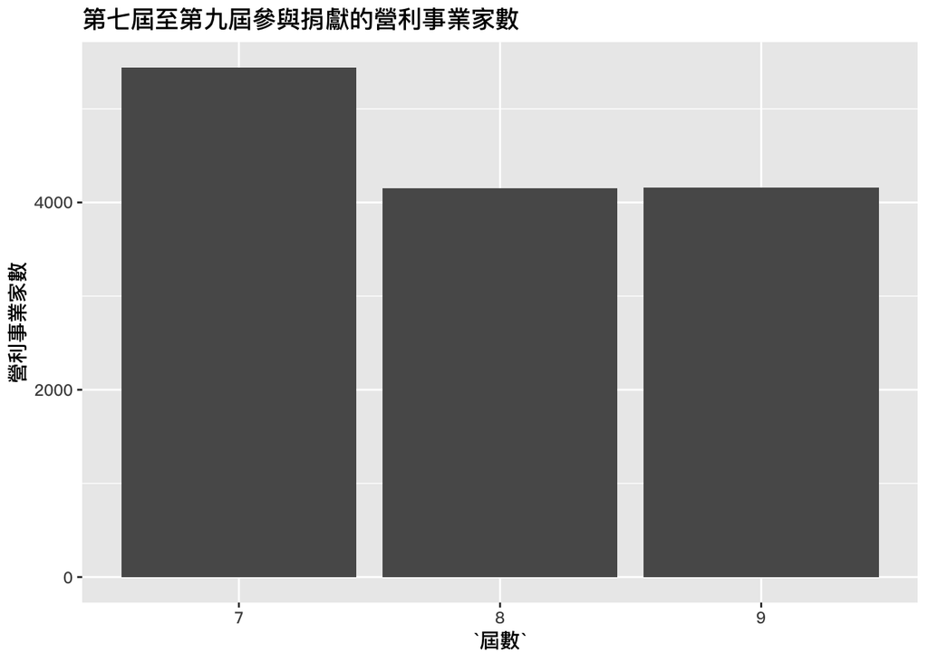

```r
donall %>%
  select(屆數, 捐贈者.支出對象) %>%
  group_by(屆數, 捐贈者.支出對象) %>%
  count(屆數, 捐贈者.支出對象) %>%
  ggplot(aes(x = 屆數)) +
  geom_bar() +
  ggtitle("第七屆至第九屆參與捐獻的營利事業家數") +
  ylab("營利事業家數") +
  theme(text = element_text(family = "PingFangTC-Medium"))
```

## 三屆的候選人營利事業捐獻金額收入情況

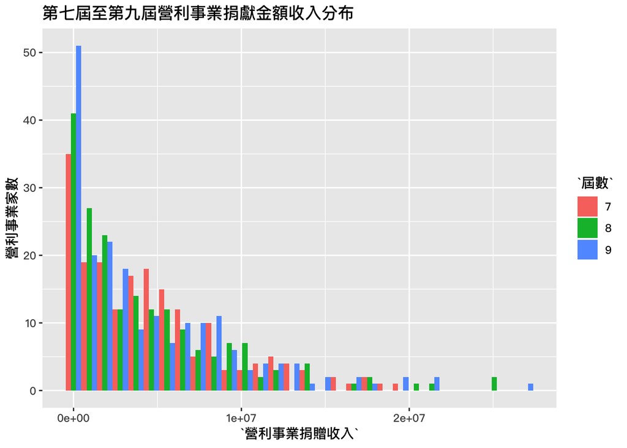

```r
perall %>%
  select(屆數, 營利事業捐贈收入, 姓名) %>%
  filter(營利事業捐贈收入 > 0) %>%
  ggplot(aes(x = 營利事業捐贈收入, fill = 屆數)) +
  geom_histogram(position = "dodge") +
  ggtitle("第七屆至第九屆營利事業捐獻金額收入分布") +
  ylab("營利事業家數") +
  theme(text = element_text(family = "PingFangTC-Medium"))
```

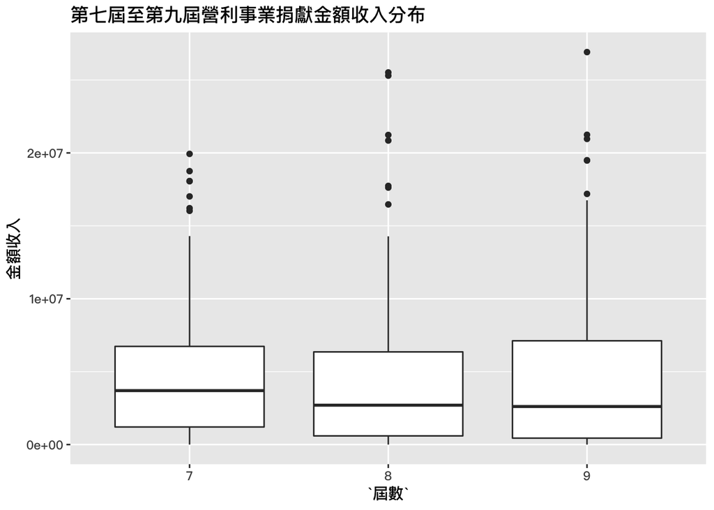

```r
perall %>%
  select(屆數, 營利事業捐贈收入, 姓名) %>%
  filter(營利事業捐贈收入 > 0) %>%
  ggplot(aes(x = 屆數, y = 營利事業捐贈收入)) +
  geom_boxplot() +
  ggtitle("第七屆至第九屆營利事業捐獻金額收入分布") +
  ylab("金額收入") +
  theme(text = element_text(family = "PingFangTC-Medium"))
```

第九屆前三名：柯建銘、邱志偉、吳秉叡。 第八屆前三名：周守訓、丁守中、吳育昇。 第七屆前三名：周守訓、林郁方、吳育昇。

## 三屆的營利事業總捐獻金額情況

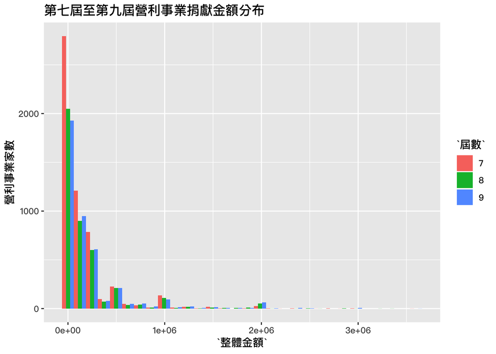

```r
donall %>%
  select(屆數, 捐贈者.支出對象, 收入金額) %>%
  group_by(屆數, 捐贈者.支出對象) %>%
  summarise(整體金額 = sum(收入金額)) %>%
  ggplot(aes(x = 整體金額, fill = 屆數)) +
  geom_histogram(position = "dodge") +
  ggtitle("第七屆至第九屆營利事業捐獻金額分布") +
  ylab("營利事業家數") +
  theme(text = element_text(family = "PingFangTC-Medium"))
```

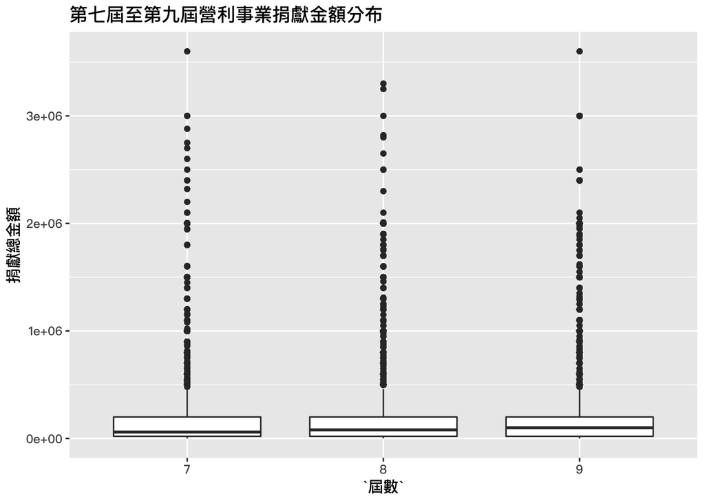

```r
donall %>%
  select(屆數, 捐贈者.支出對象, 收入金額) %>%
  group_by(屆數, 捐贈者.支出對象) %>%
  summarise(整體金額 = sum(收入金額)) %>%
  ggplot(aes(x = 屆數, y = 整體金額)) +
  geom_boxplot() +
  ggtitle("第七屆至第九屆營利事業捐獻金額分布") +
  ylab("捐獻總金額") +
  theme(text = element_text(family = "PingFangTC-Medium"))
```

第九屆前三名：中科國際物流股份有限公司、東徽企業股份有限公司、建新國際股份有限公司。 第八屆前三名：吉美建設事業股份有限公司、國美建設股份有限公司、亞東預拌混凝土股份有限公司。 第七屆前三名：大慶票券金融股份有限公司、大眾綜合證券股份有限公司、台灣櫻花股份有限公司。

## 單比捐獻金額最高

```r
donall %>%
  select(屆數, 捐贈者.支出對象, 收入金額) %>%
  group_by(屆數) %>%
  top_n(3, 收入金額)
```

```
## # A tibble: 547 x 3
## # Groups:   屆數 [3]
##    屆數  捐贈者.支出對象          收入金額
##    <chr> <chr>                       <int>
##  1 7     百揚投資股份有限公司      1000000
##  2 7     新勤股份有限公司          1000000
##  3 7     裕景實業股份有限公司      1000000
##  4 7     亞洲工程企業(股)          1000000
##  5 7     百鼎投資股份有限公司      1000000
##  6 7     鼎泰水泥股份有限公司      1000000
##  7 7     鼎固營造股份有限公司      1000000
##  8 7     大眾綜合證券股份有限公司  1000000
##  9 7     亞洲水泥股份有限公司      1000000
## 10 7     正佳營造有限公司          1000000
## # ... with 537 more rows
```

發現捐獻額最高是一百萬。

## 探討對於營利事業來說，捐獻行為是否有明顯政黨傾向（以捐獻人次來看）

我們想要知道營利企業在捐獻的時候，若它對多位的候選人進行捐獻，會有分散風險的概念，國民黨和民進黨各押一部分，或者是全押在特定政黨之上。為了達到分析的目標，將國民黨的值設定為 0，民進黨的值設定為 1，若一個企業的捐獻傾向為 0，代表他的捐獻對象全押在國民黨，若為 1 則是民進黨，為 0.5 則為兩黨各半。

然而企業捐獻傾向的值容易因為捐獻的候選人人數而有很不同的分布情況，例如只對兩位候選人捐獻的企業的捐獻傾向值，只會集中在 0, 0,5 和 1 三個值，但對大於五位候選人捐獻的企業的捐獻傾向值則會呈現相對連續的分布，故在分析上將營利企業分為三個種類。為了避免差異過大的分布融合之後無法呈現真實的捐獻傾向分布情況，我將企業根據捐獻人數分成三組，捐獻人數為 2 的為低捐獻人數企業，捐獻人數為三到五的為中捐獻人數企業，捐獻人數大於六的為高捐獻人數企業。

另外，我預設企業的捐獻行為會受到每次選舉的政治環境影響，不能一概而論，因此會針對不同的屆數來進行分析。

### 政黨傾向資料前處理

```r
donbe <- donall %>%
  select(屆數, 姓名, 捐贈者.支出對象) %>%
  group_by(屆數, 姓名, 捐贈者.支出對象) %>%
  count(捐贈者.支出對象) %>%
  ungroup() %>%
  left_join(perall, by = c("姓名" = "姓名", "屆數" = "屆數")) %>%
  select(屆數, 姓名, 捐贈者.支出對象, 推薦政黨) %>%
  filter(推薦政黨 %in% c("民主進步黨", "中國國民黨")) %>%
  group_by(屆數, 捐贈者.支出對象) %>%
  count(捐贈者.支出對象) %>%
  filter(n>1) %>%
  mutate(捐獻人數 = ifelse(n >= 1 & n <= 2, "低捐獻人數",
                       ifelse(n >= 3 & n <= 5, "中捐獻人數", "高捐獻人數"))) %>%
  rename(總捐獻人數 = n)

donba <- donall %>%
  select(屆數, 姓名, 捐贈者.支出對象) %>%
  group_by(屆數, 姓名, 捐贈者.支出對象) %>%
  count(捐贈者.支出對象) %>%
  ungroup() %>%
  left_join(perall, by = c("姓名" = "姓名", "屆數" = "屆數")) %>%
  select(屆數, 捐贈者.支出對象, 推薦政黨) %>%
  filter(推薦政黨 %in% c("民主進步黨", "中國國民黨")) %>%
  group_by(屆數, 捐贈者.支出對象, 推薦政黨) %>%
  count(捐贈者.支出對象) %>%
  ungroup() %>%
  filter(捐贈者.支出對象 %in% donbe$捐贈者.支出對象) %>%
  left_join(donbe, by = c("捐贈者.支出對象", "屆數" = "屆數")) %>%
  mutate(value = ifelse(推薦政黨 == "民主進步黨", n, 0))
```

### 低捐獻人數企業政黨傾向

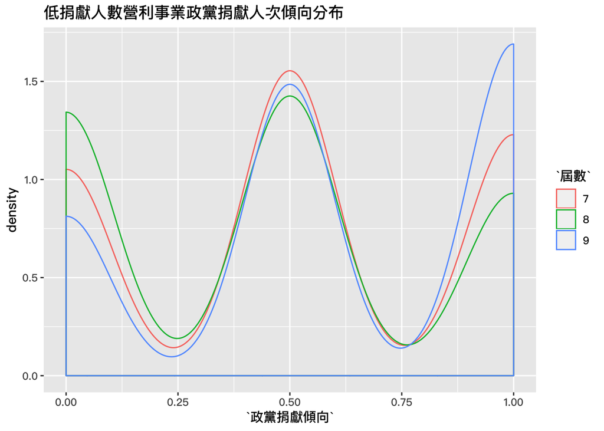

```r
donba %>%
  filter(捐獻人數 == "低捐獻人數") %>%
  group_by(屆數, 捐贈者.支出對象, 總捐獻人數) %>%
  summarise(捐獻分數 = sum(value)) %>%
  mutate(政黨捐獻傾向 = 捐獻分數/總捐獻人數) %>%
  ggplot(aes(x = 政黨捐獻傾向, colour = 屆數)) +
  geom_density() +
  ggtitle("低捐獻人數營利事業政黨捐獻人次傾向分布") +
  theme(text = element_text(family = "PingFangTC-Medium"))
```

### 中捐獻人數企業政黨傾向

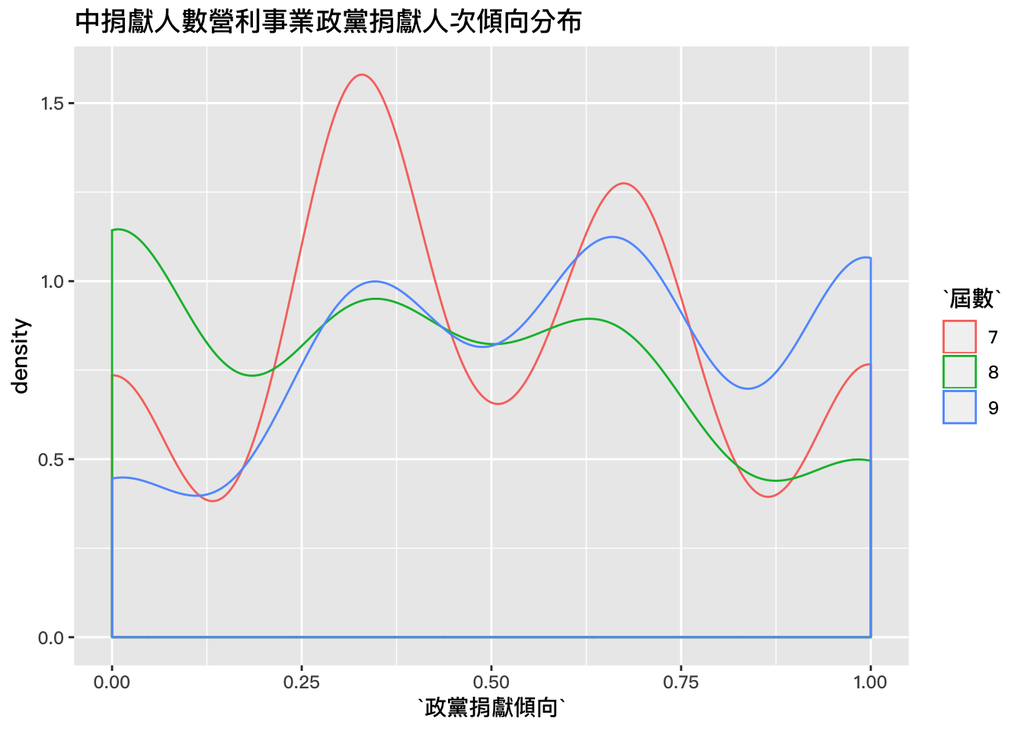

```r
donba %>%
  filter(捐獻人數 == "中捐獻人數") %>%
  group_by(屆數, 捐贈者.支出對象, 總捐獻人數) %>%
  summarise(捐獻分數 = sum(value)) %>%
  mutate(政黨捐獻傾向 = 捐獻分數/總捐獻人數) %>%
  ggplot(aes(x = 政黨捐獻傾向, colour = 屆數)) +
  geom_density() +
  ggtitle("中捐獻人數營利事業政黨捐獻人次傾向分布") +
  theme(text = element_text(family = "PingFangTC-Medium"))
```

### 高捐獻人數企業政黨傾向

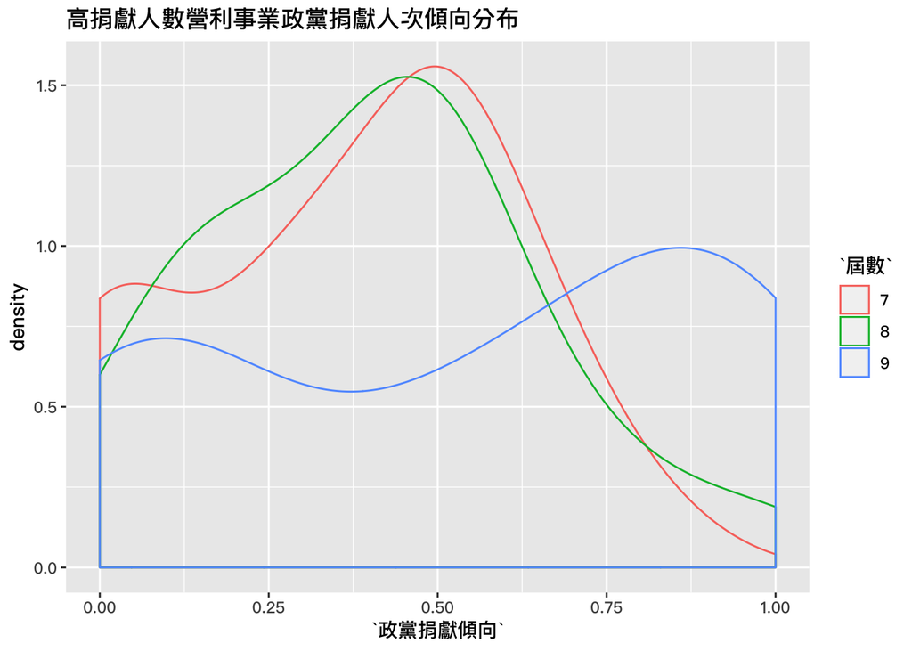

```r
donba %>%
  filter(捐獻人數 == "高捐獻人數") %>%
  group_by(屆數, 捐贈者.支出對象, 總捐獻人數) %>%
  summarise(捐獻分數 = sum(value)) %>%
  mutate(政黨捐獻傾向 = 捐獻分數/總捐獻人數) %>%
  ggplot(aes(x = 政黨捐獻傾向, colour = 屆數)) +
  geom_density() +
  ggtitle("高捐獻人數營利事業政黨捐獻人次傾向分布") +
  theme(text = element_text(family = "PingFangTC-Medium"))
```

## 探討對於營利事業來說，捐獻行為是否有明顯政黨傾向（以捐獻金額來看）

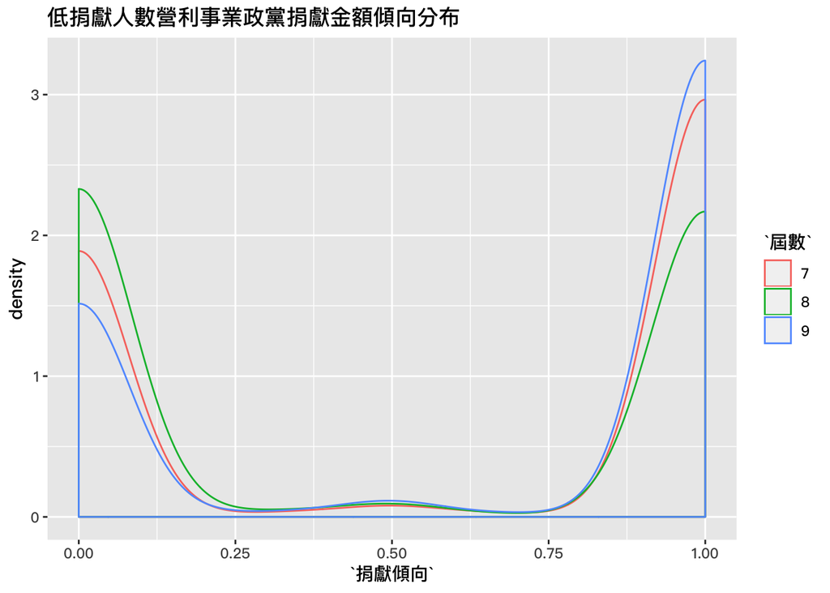

```r
donra <- donall %>%
  select(屆數, 姓名, 捐贈者.支出對象) %>%
  group_by(屆數, 姓名, 捐贈者.支出對象) %>%
  count(捐贈者.支出對象) %>%
  ungroup() %>%
  group_by(屆數, 捐贈者.支出對象) %>%
  count(捐贈者.支出對象) %>%
  mutate(捐獻人數 = ifelse(nn >= 1 & nn <= 2, "低捐獻人數",
                       ifelse(nn >= 3 & nn <= 5, "中捐獻人數", "高捐獻人數"))) %>%
  rename(總捐獻人數 = nn)

donall %>%
  left_join(perall %>% select(姓名, 屆數, 推薦政黨), by = c("姓名", "屆數")) %>%
  left_join(donra %>% select(捐贈者.支出對象, 屆數, 捐獻人數),  by = c("捐贈者.支出對象", "屆數")) %>%
  filter(推薦政黨 %in% c("中國國民黨", "民主進步黨")) %>%
  filter(捐獻人數 == "低捐獻人數") %>%
  group_by(捐贈者.支出對象, 屆數, 推薦政黨) %>%
  summarise(money = sum(收入金額)) %>%
  group_by(捐贈者.支出對象, 屆數) %>%
  mutate(all_money = sum(money), prop  = money / sum(money)) %>%
  mutate(prop = ifelse(推薦政黨 == "中國國民黨", 0 , prop)) %>%
  summarise(捐獻傾向 = sum(prop)) %>%
  ggplot(aes(x = 捐獻傾向, colour = 屆數)) +
  geom_density() +
  ggtitle("低捐獻人數營利事業政黨捐獻金額傾向分布") +
  theme(text = element_text(family = "PingFangTC-Medium"))
```

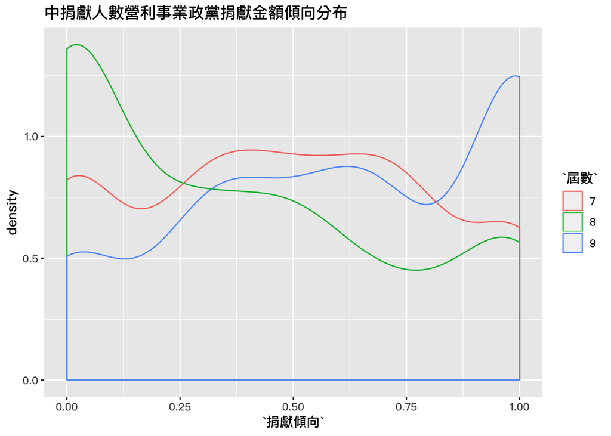

```r
donall %>%
  left_join(perall %>% select(姓名, 屆數, 推薦政黨), by = c("姓名", "屆數")) %>%
  left_join(donra %>% select(捐贈者.支出對象, 屆數, 捐獻人數),  by = c("捐贈者.支出對象", "屆數")) %>%
  filter(推薦政黨 %in% c("中國國民黨", "民主進步黨")) %>%
  filter(捐獻人數 == "中捐獻人數") %>%
  group_by(捐贈者.支出對象, 屆數, 推薦政黨) %>%
  summarise(money = sum(收入金額)) %>%
  group_by(捐贈者.支出對象, 屆數) %>%
  mutate(all_money = sum(money), prop  = money / sum(money)) %>%
  mutate(prop = ifelse(推薦政黨 == "中國國民黨", 0 , prop)) %>%
  summarise(捐獻傾向 = sum(prop)) %>%
  ggplot(aes(x = 捐獻傾向, colour = 屆數)) +
  geom_density() +
  ggtitle("中捐獻人數營利事業政黨捐獻金額傾向分布") +
  theme(text = element_text(family = "PingFangTC-Medium"))
```

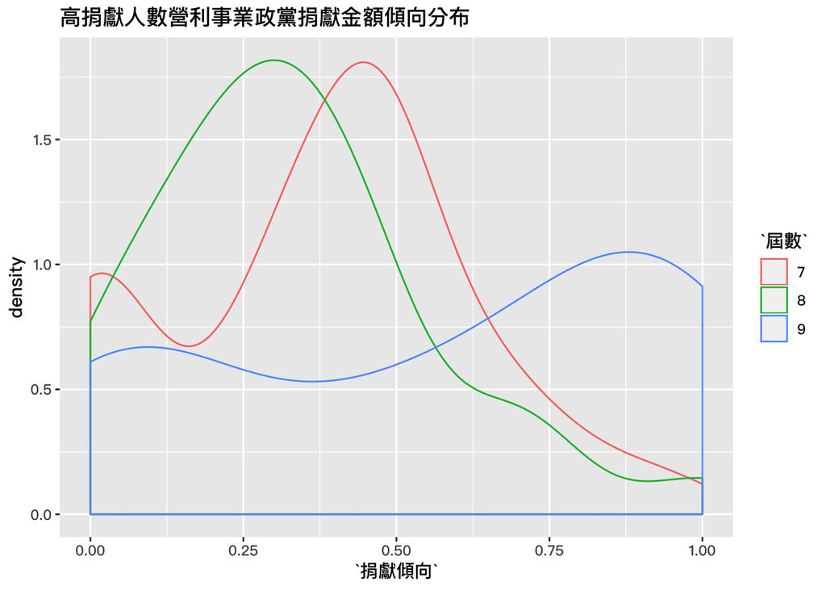

```r
donall %>%
  left_join(perall %>% select(姓名, 屆數, 推薦政黨), by = c("姓名", "屆數")) %>%
  left_join(donra %>% select(捐贈者.支出對象, 屆數, 捐獻人數),  by = c("捐贈者.支出對象", "屆數")) %>%
  filter(推薦政黨 %in% c("中國國民黨", "民主進步黨")) %>%
  filter(捐獻人數 == "高捐獻人數") %>%
  group_by(捐贈者.支出對象, 屆數, 推薦政黨) %>%
  summarise(money = sum(收入金額)) %>%
  group_by(捐贈者.支出對象, 屆數) %>%
  mutate(all_money = sum(money), prop  = money / sum(money)) %>%
  mutate(prop = ifelse(推薦政黨 == "中國國民黨", 0 , prop)) %>%
  summarise(捐獻傾向 = sum(prop)) %>%
  ggplot(aes(x = 捐獻傾向, colour = 屆數)) +
  geom_density() +
  ggtitle("高捐獻人數營利事業政黨捐獻金額傾向分布") +
  theme(text = element_text(family = "PingFangTC-Medium"))
```

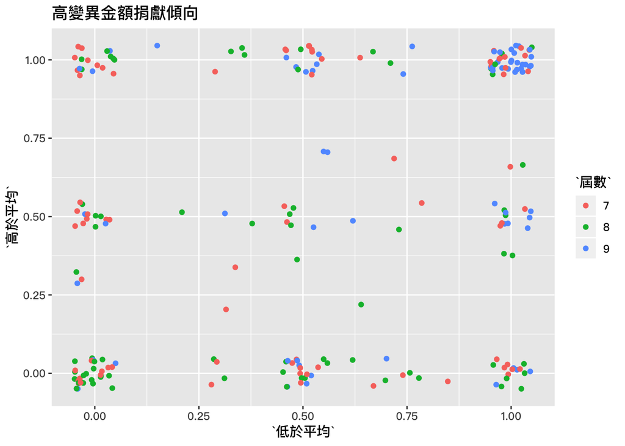

```r
don_var <- donall %>%
  left_join(perall %>% select(姓名, 屆數, 推薦政黨), by = c("姓名", "屆數")) %>%
  left_join(donra %>% select(捐贈者.支出對象, 屆數, 捐獻人數),  by = c("捐贈者.支出對象", "屆數")) %>%
  filter(推薦政黨 %in% c("中國國民黨", "民主進步黨")) %>%
  filter(!捐獻人數 == "低捐獻人數") %>%
  group_by(屆數, 捐贈者.支出對象, 姓名) %>%
  mutate(sum_per = sum(收入金額)) %>%
  distinct(屆數, 捐贈者.支出對象, 姓名, .keep_all = TRUE) %>%
  group_by(屆數, 捐贈者.支出對象) %>%
  summarise(mean = mean(sum_per), sd = sd(sum_per), cv = sd(sum_per) / mean(sum_per)) %>%
  filter(cv >= 0.5)
don_var %>%
  left_join(donall, , by = c("捐贈者.支出對象", "屆數")) %>%
  group_by(捐贈者.支出對象, 屆數, 姓名) %>%
  mutate(收入金額 = sum(收入金額)) %>%
  distinct(屆數, 捐贈者.支出對象, 姓名, .keep_all = TRUE) %>%
  left_join(perall %>% select(姓名, 屆數, 推薦政黨), by = c("姓名", "屆數")) %>%
  filter(推薦政黨 %in% c("中國國民黨", "民主進步黨")) %>%
  mutate(是否高於平均 = case_when(收入金額 >= mean ~ "高於平均", TRUE ~ "低於平均"),
         政黨傾向 = case_when(推薦政黨 == "民主進步黨" ~ 1, TRUE ~ 0)) %>%
  group_by(捐贈者.支出對象, 屆數, 是否高於平均) %>%
  mutate(分類總數 = n()) %>%
  group_by(捐贈者.支出對象, 屆數, 推薦政黨, 是否高於平均) %>%
  mutate(政黨傾向 = sum(政黨傾向)) %>%
  distinct(捐贈者.支出對象, 屆數, 推薦政黨, 是否高於平均, .keep_all = TRUE) %>%
  group_by(捐贈者.支出對象, 屆數, 是否高於平均) %>%
  mutate(政黨傾向 = sum(政黨傾向)) %>%
  distinct(捐贈者.支出對象, 屆數, 是否高於平均, .keep_all = TRUE) %>%
  mutate(result = 政黨傾向 / 分類總數) %>%
  spread(是否高於平均, result, fill = 0) %>%
  group_by(捐贈者.支出對象, 屆數) %>%
  summarise(低於平均 = sum(低於平均), 高於平均 = sum(高於平均)) %>%
  ggplot() +
  aes(x = 低於平均, y = 高於平均, color = 屆數) %>%
  geom_jitter(width=0.05,height=0.05) +
  ggtitle("高變異金額捐獻傾向") +
  theme(text = element_text(family = "PingFangTC-Medium"))
```

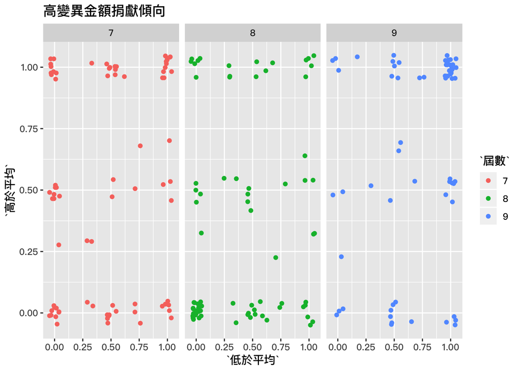

```r
don_var %>%
  left_join(donall, , by = c("捐贈者.支出對象", "屆數")) %>%
  group_by(捐贈者.支出對象, 屆數, 姓名) %>%
  mutate(收入金額 = sum(收入金額)) %>%
  distinct(屆數, 捐贈者.支出對象, 姓名, .keep_all = TRUE) %>%
  left_join(perall %>% select(姓名, 屆數, 推薦政黨), by = c("姓名", "屆數")) %>%
  filter(推薦政黨 %in% c("中國國民黨", "民主進步黨")) %>%
  mutate(是否高於平均 = case_when(收入金額 >= mean ~ "高於平均", TRUE ~ "低於平均"),
         政黨傾向 = case_when(推薦政黨 == "民主進步黨" ~ 1, TRUE ~ 0)) %>%
  group_by(捐贈者.支出對象, 屆數, 是否高於平均) %>%
  mutate(分類總數 = n()) %>%
  group_by(捐贈者.支出對象, 屆數, 推薦政黨, 是否高於平均) %>%
  mutate(政黨傾向 = sum(政黨傾向)) %>%
  distinct(捐贈者.支出對象, 屆數, 推薦政黨, 是否高於平均, .keep_all = TRUE) %>%
  group_by(捐贈者.支出對象, 屆數, 是否高於平均) %>%
  mutate(政黨傾向 = sum(政黨傾向)) %>%
  distinct(捐贈者.支出對象, 屆數, 是否高於平均, .keep_all = TRUE) %>%
  mutate(result = 政黨傾向 / 分類總數) %>%
  spread(是否高於平均, result, fill = 0) %>%
  group_by(捐贈者.支出對象, 屆數) %>%
  summarise(低於平均 = sum(低於平均), 高於平均 = sum(高於平均)) %>%
  ggplot() +
  aes(x = 低於平均, y = 高於平均, color = 屆數) %>%
  geom_jitter(width=0.05,height=0.05) +
  ggtitle("高變異金額捐獻傾向") +
  theme(text = element_text(family = "PingFangTC-Medium")) +
  facet_wrap(~ 屆數)
```

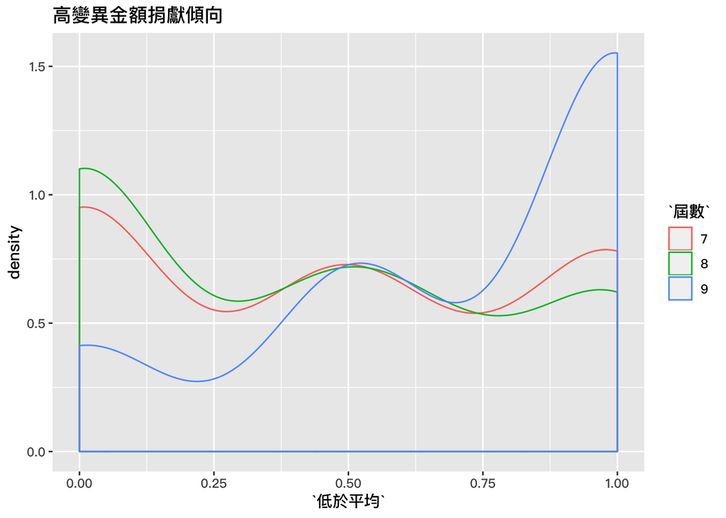

```r
don_var %>%
  left_join(donall, , by = c("捐贈者.支出對象", "屆數")) %>%
  group_by(捐贈者.支出對象, 屆數, 姓名) %>%
  mutate(收入金額 = sum(收入金額)) %>%
  distinct(屆數, 捐贈者.支出對象, 姓名, .keep_all = TRUE) %>%
  left_join(perall %>% select(姓名, 屆數, 推薦政黨), by = c("姓名", "屆數")) %>%
  filter(推薦政黨 %in% c("中國國民黨", "民主進步黨")) %>%
  mutate(是否高於平均 = case_when(收入金額 >= mean ~ "高於平均", TRUE ~ "低於平均"),
         政黨傾向 = case_when(推薦政黨 == "民主進步黨" ~ 1, TRUE ~ 0)) %>%
  group_by(捐贈者.支出對象, 屆數, 是否高於平均) %>%
  mutate(分類總數 = n()) %>%
  group_by(捐贈者.支出對象, 屆數, 推薦政黨, 是否高於平均) %>%
  mutate(政黨傾向 = sum(政黨傾向)) %>%
  distinct(捐贈者.支出對象, 屆數, 推薦政黨, 是否高於平均, .keep_all = TRUE) %>%
  group_by(捐贈者.支出對象, 屆數, 是否高於平均) %>%
  mutate(政黨傾向 = sum(政黨傾向)) %>%
  distinct(捐贈者.支出對象, 屆數, 是否高於平均, .keep_all = TRUE) %>%
  mutate(result = 政黨傾向 / 分類總數) %>%
  spread(是否高於平均, result, fill = 0) %>%
  group_by(捐贈者.支出對象, 屆數) %>%
  summarise(低於平均 = sum(低於平均), 高於平均 = sum(高於平均)) %>%
  ggplot() +
  aes(x = 低於平均, color = 屆數) %>%
  geom_density() +
  ggtitle("高變異金額捐獻傾向") +
  theme(text = element_text(family = "PingFangTC-Medium"))
```

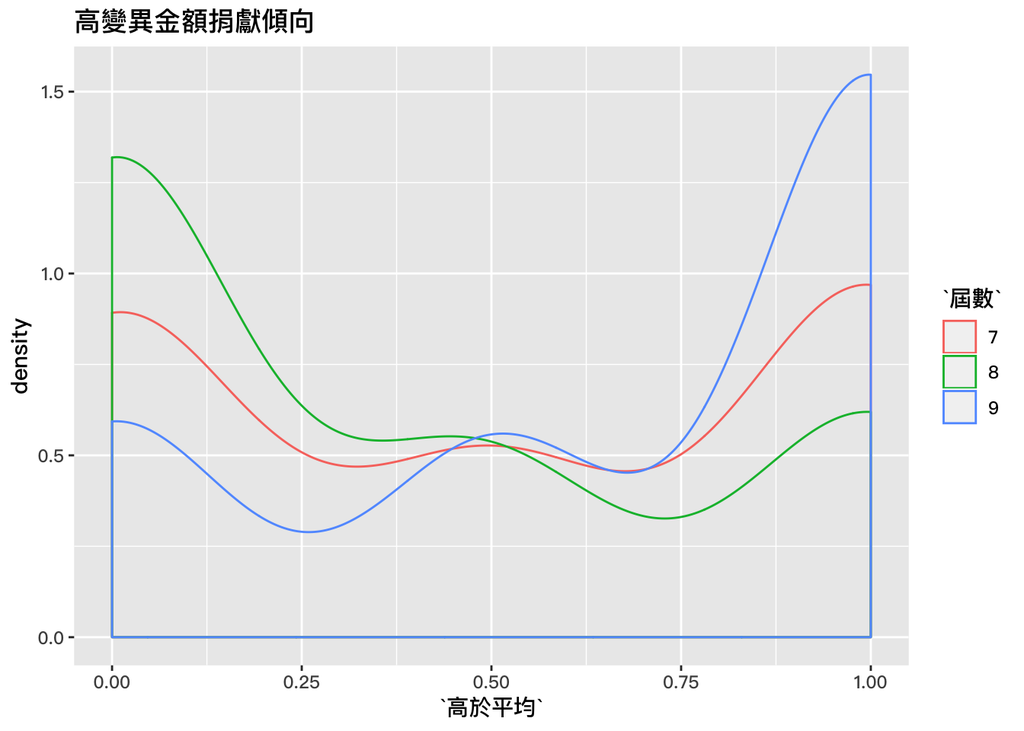

```r
don_var %>%
  left_join(donall, , by = c("捐贈者.支出對象", "屆數")) %>%
  group_by(捐贈者.支出對象, 屆數, 姓名) %>%
  mutate(收入金額 = sum(收入金額)) %>%
  distinct(屆數, 捐贈者.支出對象, 姓名, .keep_all = TRUE) %>%
  left_join(perall %>% select(姓名, 屆數, 推薦政黨), by = c("姓名", "屆數")) %>%
  filter(推薦政黨 %in% c("中國國民黨", "民主進步黨")) %>%
  mutate(是否高於平均 = case_when(收入金額 >= mean ~ "高於平均", TRUE ~ "低於平均"),
         政黨傾向 = case_when(推薦政黨 == "民主進步黨" ~ 1, TRUE ~ 0)) %>%
  group_by(捐贈者.支出對象, 屆數, 是否高於平均) %>%
  mutate(分類總數 = n()) %>%
  group_by(捐贈者.支出對象, 屆數, 推薦政黨, 是否高於平均) %>%
  mutate(政黨傾向 = sum(政黨傾向)) %>%
  distinct(捐贈者.支出對象, 屆數, 推薦政黨, 是否高於平均, .keep_all = TRUE) %>%
  group_by(捐贈者.支出對象, 屆數, 是否高於平均) %>%
  mutate(政黨傾向 = sum(政黨傾向)) %>%
  distinct(捐贈者.支出對象, 屆數, 是否高於平均, .keep_all = TRUE) %>%
  mutate(result = 政黨傾向 / 分類總數) %>%
  spread(是否高於平均, result, fill = 0) %>%
  group_by(捐贈者.支出對象, 屆數) %>%
  summarise(低於平均 = sum(低於平均), 高於平均 = sum(高於平均)) %>%
  ggplot() +
  aes(x = 高於平均, color = 屆數) %>%
  geom_density() +
  ggtitle("高變異金額捐獻傾向") +
  theme(text = element_text(family = "PingFangTC-Medium"))
```

```r
don_3 <- donall %>%
  group_by(屆數, 捐贈者.支出對象) %>%
  count(屆數, 捐贈者.支出對象) %>%
  group_by(捐贈者.支出對象) %>%
  count(捐贈者.支出對象) %>%
  filter(nn == 3)
```

```r
don_kuo <- donall %>%
  filter(捐贈者.支出對象 %in% don_3$捐贈者.支出對象) %>%
  left_join(perall %>% select(姓名, 屆數, 推薦政黨), by = c("姓名", "屆數")) %>%
  mutate(value = case_when(推薦政黨 == "中國國民黨" ~ 0, TRUE ~ 1)) %>%
  group_by(屆數, 捐贈者.支出對象) %>%
  summarise(all = sum(value)) %>%
  group_by(捐贈者.支出對象) %>%
  summarise(a = sum(all)) %>%
  filter(a == 0)

don_min <- donall %>%
  filter(捐贈者.支出對象 %in% don_3$捐贈者.支出對象) %>%
  left_join(perall %>% select(姓名, 屆數, 推薦政黨), by = c("姓名", "屆數")) %>%
  mutate(value = case_when(推薦政黨 == "中國國民黨" ~ 1, TRUE ~ 0)) %>%
  group_by(屆數, 捐贈者.支出對象) %>%
  summarise(all = sum(value)) %>%
  group_by(捐贈者.支出對象) %>%
  summarise(a = sum(all)) %>%
  filter(a == 0)
```

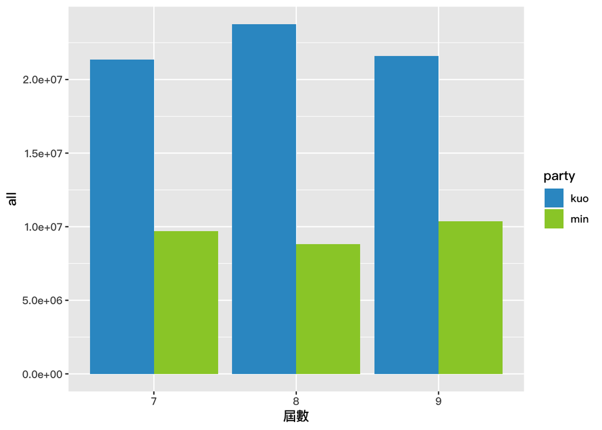

```r
donall %>%
  filter(捐贈者.支出對象 %in% c(don_kuo$捐贈者.支出對象, don_min$捐贈者.支出對象)) %>%
  mutate(party = case_when(捐贈者.支出對象 %in% don_kuo$捐贈者.支出對象 ~ "kuo",
                           TRUE ~ "min")) %>%
  group_by(屆數, party) %>%
  summarise(all = sum(收入金額)) %>%
  ggplot() +
  aes(x = 屆數, y = all, fill = party) +
  geom_bar(stat = "identity", position = "dodge") +
  theme(text = element_text(family = "PingFangTC-Medium")) +
  scale_fill_manual(values=c("#3399CC", "#99CC33"))
```

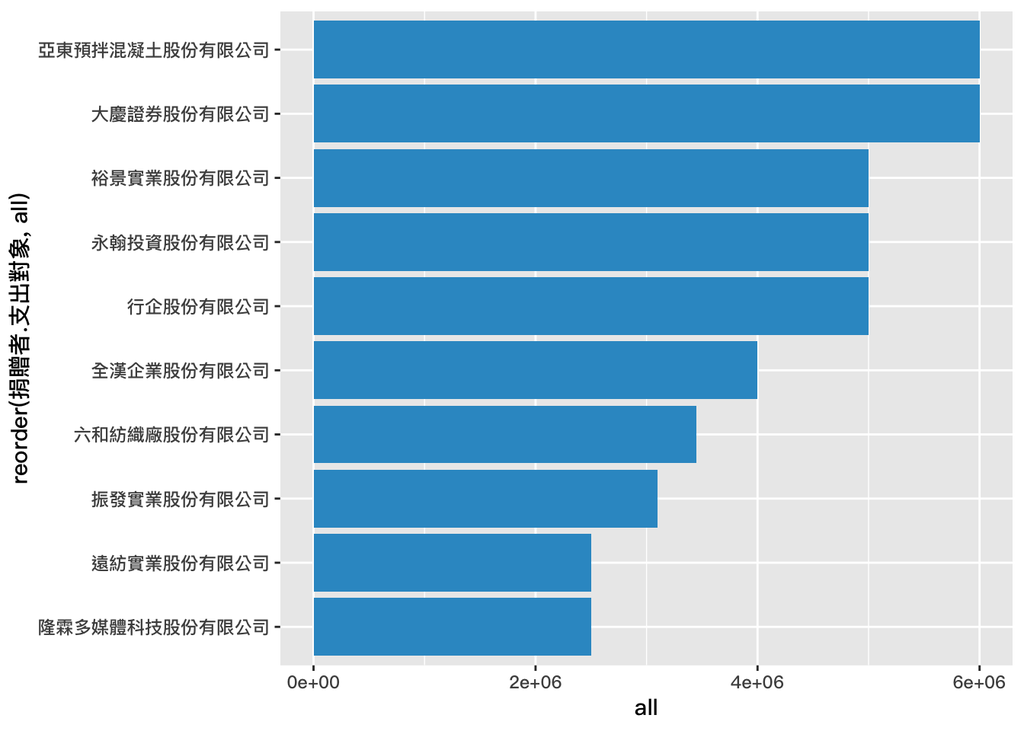

```r
donall %>%
  filter(捐贈者.支出對象 %in% don_kuo$捐贈者.支出對象) %>%
  group_by(捐贈者.支出對象) %>%
  summarise(all = sum(收入金額)) %>%
  arrange(desc(all)) %>%
  head(10) %>%
  ggplot() +
  aes(x = reorder(捐贈者.支出對象, all), y = all) +
  geom_bar(stat = "identity", fill = "#3399CC") +
  coord_flip() +
  theme(text = element_text(family = "PingFangTC-Medium"))
```

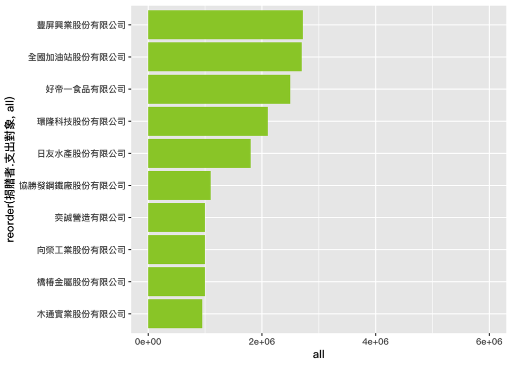

```r
donall %>%
  filter(捐贈者.支出對象 %in% don_min$捐贈者.支出對象) %>%
  group_by(捐贈者.支出對象) %>%
  summarise(all = sum(收入金額)) %>%
  arrange(desc(all)) %>%
  head(10) %>%
  ggplot() +
  aes(x = reorder(捐贈者.支出對象, all), y = all) +
  geom_bar(stat = "identity", fill = "#99CC33") +
  coord_flip() +
  theme(text = element_text(family = "PingFangTC-Medium")) +
  ylim(0, 6000000)
```